# The Quantum Fourier Transform

writer : ericedu1

date : 20230613

# The quantum Fourier transform

## 1 Introduction to quantum Fourier transform

On the field of algorithms, when we encounter hard problems to solve, the powerful way to solve the problem could be the method called *transfrom* which is tranforming hard problem basis to one that easier to solve. One of the advantages of using quantum computer rather than classical one is transforming algorithms are way faster than one of classical computer. The quantum Fourier transform we want to explain on this chapter is one of the transform.

**Definition.** Discrete Fourier Transform

for vector in complex space, $\vec x \rightarrow \vec y$ transform is defined as,

$$y_k\equiv\frac 1 {\sqrt N}\sum_{j=0}^{N-1}x_je^{2\pi ijk/N}\tag{1}$$

Before explain what quantum fourier transform is, we need to know what discrete Fourier transform is. For two vectors in N dimensional space, we can write summation in definition of discrete fourier transform as matrix product.

$$Q_{k,j}=\frac 1 {\sqrt{N}}[(e^{\frac{2\pi i}{N}})^{k}]^j\tag{2}$$

Then, we can understand it intuitively. When we devide unit circle on complex plane N, choose k sector form and product it j times on j-th index of $\vec x$. Then we can under stand it as phase shift on each vector basis. And we can notice that if $gcd(N,k)\neq 1$, same phase shift is reapeated $gcd(N,k)$ times. Than we can link our understanding to discretized wave which gets $N/gcd(N,k)$ as $\lambda$. So, this transform will be unique to each index. Now it is easy to move this operator to Hilbert space.

$$\ket j=Q\ket k=\sum^{N-1}_{j=0}Q_{jk}\ket k\tag{3}$$

For $\ket \psi=\sum_kx_k\ket k$, transform is

$$\ket\psi\rightarrow\sum^{N-1}_{j=0}y_j\ket j\tag{4}$$

$$Q_{kj}=\frac 1 {2^{n/2}}[(e^{\frac{2\pi i}{2^n}})^k]^j\tag5$$

## 2 Binary Number representation

We set j as number from 0 to $2^n-1$ to build Fourier transform. When we write computational basis like $\ket{0101011101}$, we need a mapping between j and it’s computational basis. Usually in computer science, we use Binary Number as mapping.

**Definition.** Binary Number, Binary fraction

When we represent $\{0,1\}^n$ string as $j=j_{1}j_{2}j_{3}\cdots j_{n}$, we can mapping it in to decimal number like this definition.

$$j=j_12^{n-1}+j_22^{n-2}+\cdots + j_n2^0\tag6$$

for this, we can write binary fraction as

$$0.j_lj_{l+1}\cdots j_m=j_l/2+j_{l+1}/2^2+\cdots j_m/2^{m-l+1}\tag7$$

For decimal fractions,

$$\begin{align*}
&0.a_la_{l-1}\cdots a_m\times
10^n\\&=a_l10^{n-1}+a_{l-1}10^{n-2}+\cdots+a_{l-n+1}10^0+a_{l-n+2}10^{-1}+\cdots
a_m10^{m-l+1-n}\tag8
\end{align*}$$

Check in binary fraction

$$\begin{align*}
&0.j_lj_{l-1}\cdots j_m\times
2^n\\&=j_l2^{n-1}+j_{l-1}2^{n-2}+\cdots+j_{l-n+1}2^0+j_{l-n+2}2^{-1}+\cdots
j_m2^{m-l+1-n}\tag9
\end{align*}$$

So we can change $j=j_12^{n-1}+j_22^{n-2}+\cdots + j_n2^0$ as this

$$\begin{align*}
j2^{-l}&=j_12^{n-l-1}+j_22^{n-l-2}+\cdots +
j_n2^{-l}\\&=j_1j_2\cdots j_{n-l}.j_{n-l+1}\cdots j_{n(2)}\tag{10}
\end{align*}$$

## 3 QFT Circuit

Our Quantum Fourier Transform follow this representation.

$$\ket{j}=\frac 1{\sqrt N}\sum_ke^{2\pi ijk/N}\ket k\tag{11}$$

We can change it to binary representation like,

$$\begin{align}\ket j&=\frac 1 {2^{n/2}}\sum_k[(e^{\frac{2\pi
i}{2^n}})^k]^j\ket k \\&=\frac 1 {2^{n/2}}\sum_Ke^{2\pi ijK}\ket
K\\&=\frac 1 {2^{n/2}}\sum_Ke^{2\pi ij\sum_mk_m/2^m}\ket
K\\&=\frac 1 {2^{n/2}}\bigotimes_{m=1}^n[\sum_{k_m=0}^1(e^{2\pi
ijk_m/2^m}\ket {k_m})]\\&=\frac 1 {2^{n/2}}\bigotimes_{m=1}^n(\ket
0+e^{2\pi ij/2^m}\ket 1)\\&=\frac 1{2^{n/2}}(\ket 0+e^{2\pi
ij2^{-1}}\ket 1)(\ket 0+e^{2\pi ij2^{-2}}\ket 1)\cdots(\ket 0+e^{2\pi
ij2^{-n}}\ket 1)\\&=\frac 1 {2^{n/2}}(\ket 0+e^{2\pi i0.j_n}\ket
1)(\ket 0+e^{2\pi i0.j_{n-1}j_{n}}\ket 1)\cdots(\ket 0+e^{2\pi
i0.j_1\cdots j_{n-1}j_{n}}\ket 1)\end{align}\tag{12}$$

For k-th qubit, we want $(\ket0+e^{2\pi i0.j_{n-k+1}\cdots j_n}\ket 1)$. For build this state, First, we need to build controlled Rotation operator for Z-axis.

$$R_k=R_z(\frac{2\pi}{2^k})\tag{13}$$

When we initialize our k-th qubit’s state as $\ket {j_k}$ and we put hadamard on our state, then our state will be like

$$\hat H\ket{j_k}=\ket0+e^{2\pi i 0.j_k}\ket1\tag{14}$$

Next, if we build controlled-$R_k$ (target-$j_k$, controll-$j_{k+1}$), we can represent our state as,

$$\hat{CR_2}\hat H\ket{j_k}=\ket0+e^{2\pi i0.j_kj_{k+1}}\ket1\tag{15}$$

So, we can now put $CR_3\cdots CR_{n-k+1}$ to our state, then we can build state,

$$\hat {CR_{n-k+1}}\cdots\hat {CR_{2}}\hat H\ket{j_k}=\ket0+e^{2\pi
i0.j_k\cdots j_n}\ket1\tag{16}$$

At last, we want our k-th qubit has $\ket0+e^{2\pi i0.j_{n-k+1}\cdots j_n}\ket 1$ state, we can swap this state with $n-k+1$-th qubit. So our circuit will be like

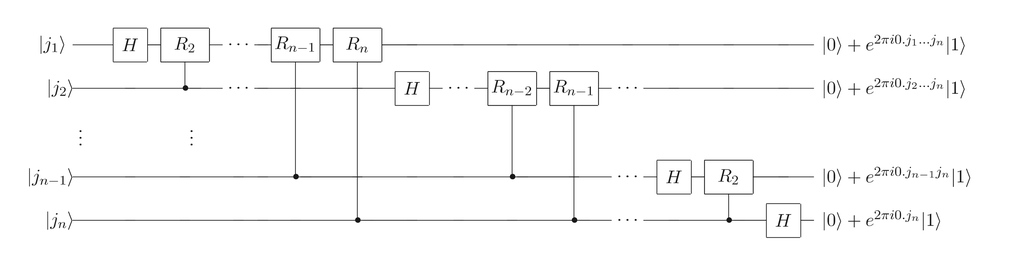

$$\ket j\rightarrow\frac 1 {2^{n/2}}(\ket 0+e^{2\pi i0.j_n}\ket 1)(\ket
0+e^{2\pi i0.j_{n-1}j_{n}}\ket 1)\cdots(\ket 0+e^{2\pi i0.j_1\cdots
j_{n-1}j_{n}}\ket 1)$$

## 4 Complexity of QFT

For our circuit, we can build a function of the number of operations with number of qubits. For swap, we need at most $n/2$ swap, and a single swap needs 3 CNOTs. For total circuit, we need $n+n-1+\cdots+2+1=n(n+1)/2$ gates, so we can say our circuit’s complexity as $O(n^2)$.

reference. Quantum Computation and Quantum Information, Nielson&chuang

To main page